# Lab 02 - Plastic waste

Vanessa Gill

02/08/2021

## Load packages and data

```r
library(tidyverse)
```

```r
plastic_waste <- read_csv("data/plastic-waste.csv")
```

## Exercises

### Exercise 1

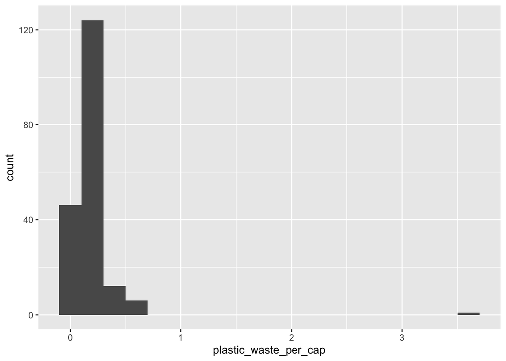

```r
ggplot(data = plastic_waste, aes(x = plastic_waste_per_cap)) +
  geom_histogram(binwidth = 0.2)
```

```r
plastic_waste %>%
  filter(plastic_waste_per_cap > 3.5)
```

```
## # A tibble: 1 x 10
##   code  entity continent  year gdp_per_cap plastic_waste_p… mismanaged_plas…
##   <chr> <chr>  <chr>     <dbl>       <dbl>            <dbl>            <dbl>
## 1 TTO   Trini… North Am…  2010      31261.              3.6             0.19
## # … with 3 more variables: mismanaged_plastic_waste <dbl>, coastal_pop <dbl>,
## #   total_pop <dbl>
```

I hadn’t given it much thought but I didn’t know plastic waste was so high in Trinidad and Tobago. Maybe it’s because their islands which makes waste management more difficult.

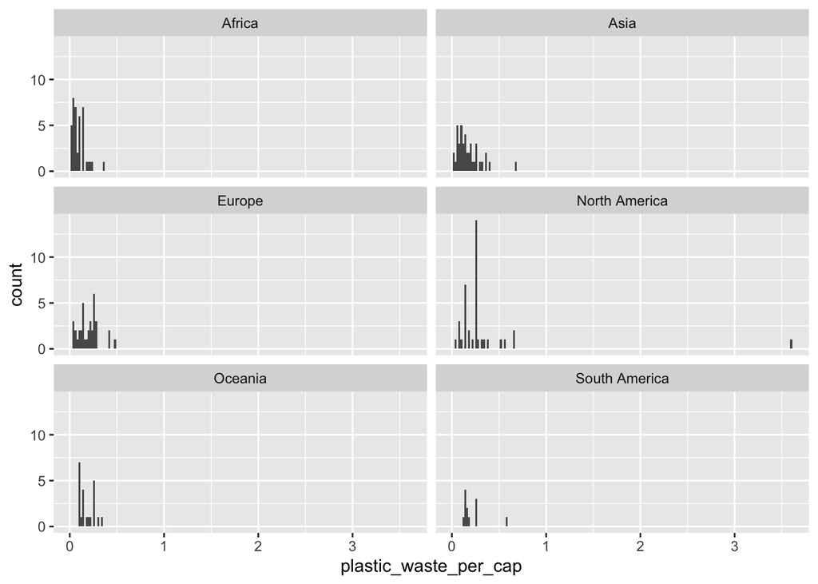

```r
ggplot(data = plastic_waste, aes(x = plastic_waste_per_cap)) +
  geom_histogram(binwidth = 0.02) +
  facet_wrap (~ continent, ncol = 2) +
  theme(legend.position = "none")
```

### Exercise 2

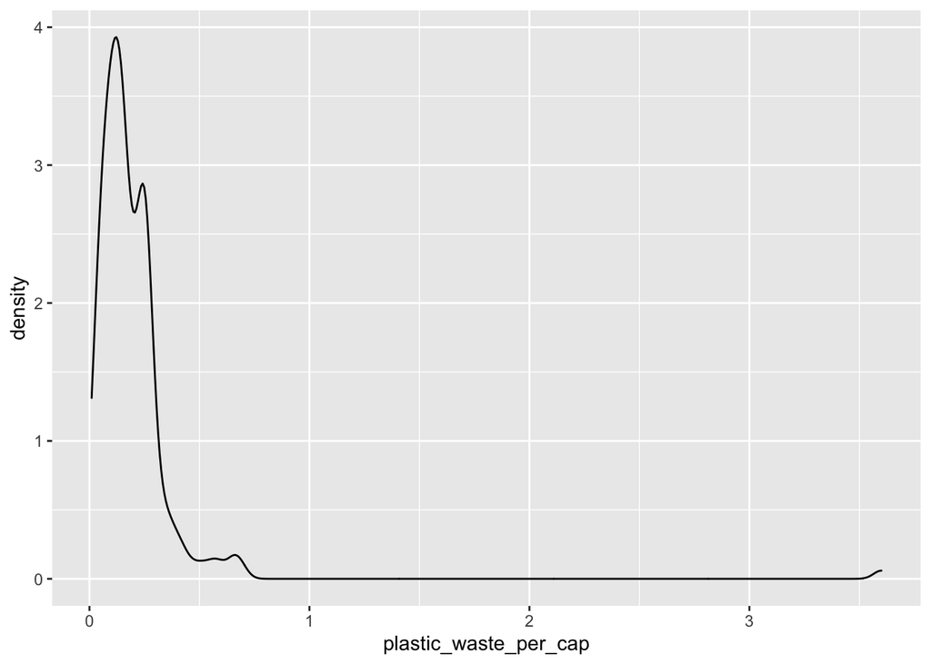

```r
ggplot(data = plastic_waste, aes(x = plastic_waste_per_cap)) +
  geom_density()
```

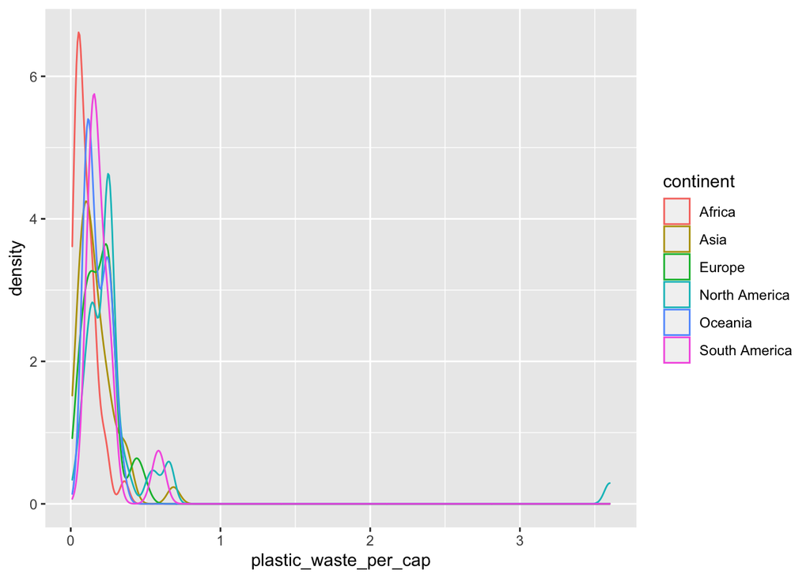

```r
ggplot(data = plastic_waste,
       mapping = aes(x = plastic_waste_per_cap,
                     color = continent)) +
  geom_density()
```

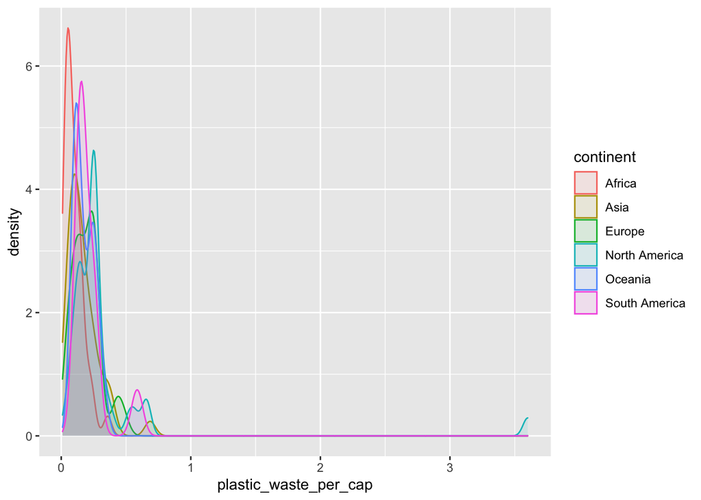

```r
ggplot(data = plastic_waste,
       mapping = aes(x = plastic_waste_per_cap,
                     color = continent,
                     fill = continent)) +
  geom_density(alpha = 0.1)
```

I think we defined color and fill of the curves by mapping aesthetics because but alpha as a characteristic because the alpha affects everything as a whole but the color and fill are specific to given chart elements.

### Exercise 3

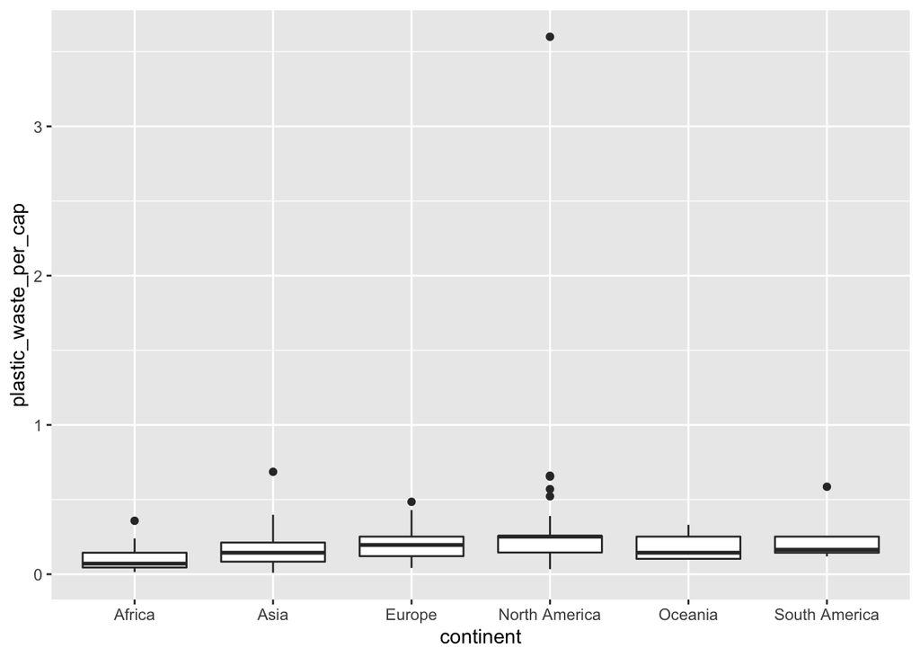

```r
ggplot(data = plastic_waste,
       mapping = aes(x = continent,
                     y = plastic_waste_per_cap)) +
  geom_boxplot()
```

### Exercise 4

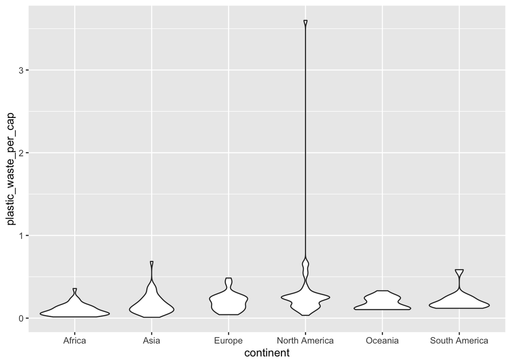

```r
ggplot(data = plastic_waste,
       mapping = aes(x = continent,
                     y = plastic_waste_per_cap)) +
  geom_violin()
```

The violin plot makes the shape of the distribution more apparent.

### Exercise 5

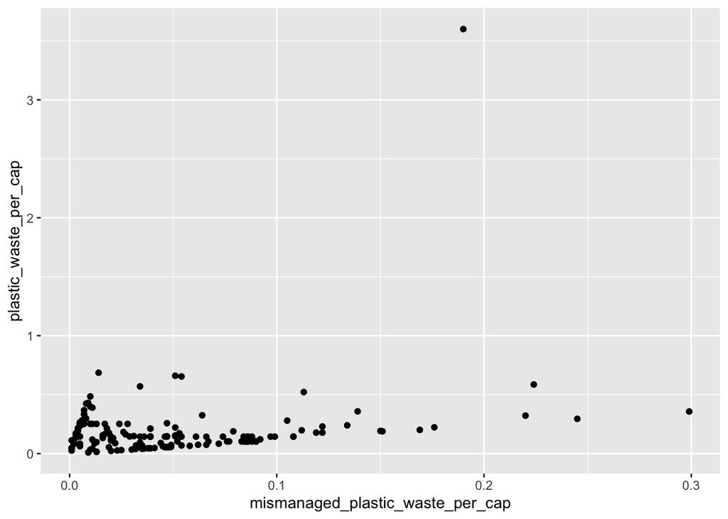

```r
ggplot(data = plastic_waste,
       mapping = aes(x = mismanaged_plastic_waste_per_cap, y = plastic_waste_per_cap)) +
       geom_point()
```

I think this is a weak linear relationship. With more plastic waste, there is more mismanaged plastic waste for the most part.

### Exercise 6

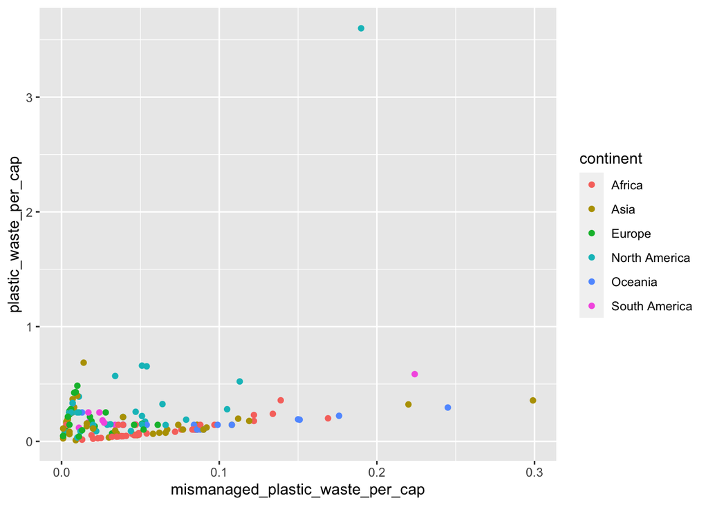

```r
ggplot(data = plastic_waste,
       mapping = aes(x = mismanaged_plastic_waste_per_cap, y = plastic_waste_per_cap, color = continent)) +
       geom_point()
```

In Europe, it appears that there’s a strong relationship whereby the more plastic waste per capita, the more mismanaged plastic waste there is. Other continents seem to have relationships that are less steep but are similar in that more waste is related to more mismanaged waste.

### Exercise 7

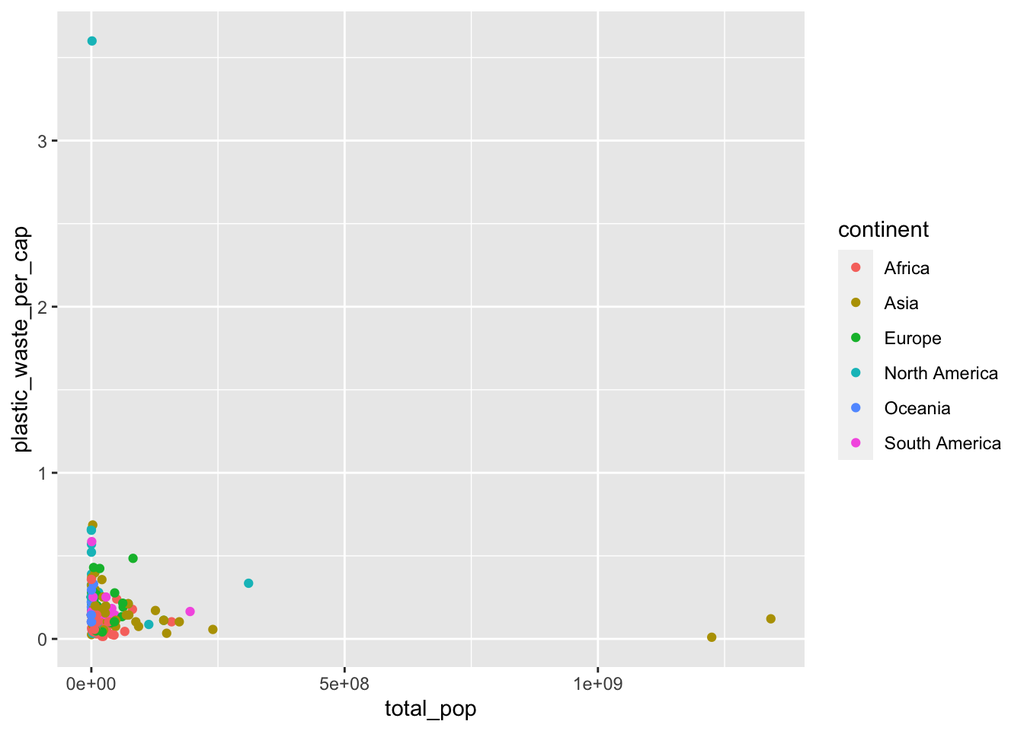

```r
ggplot(data = plastic_waste,
       mapping = aes(x = total_pop, y = plastic_waste_per_cap, color = continent)) +
       geom_point()
```

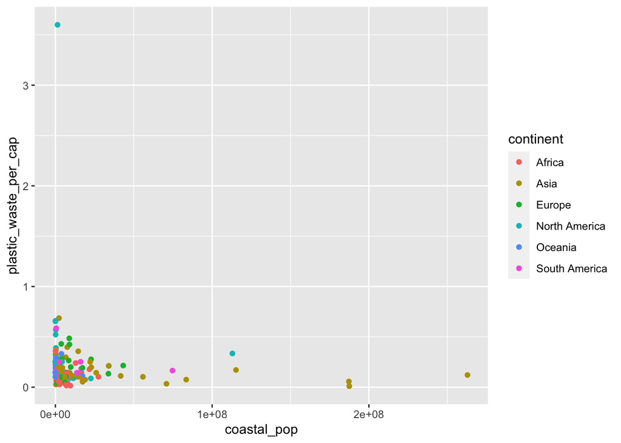

```r
ggplot(data = plastic_waste,
       mapping = aes(x = coastal_pop, y = plastic_waste_per_cap, color = continent)) +
       geom_point()
```

It appears the coastal population data has a stronger linear relationship

### Exercise 8

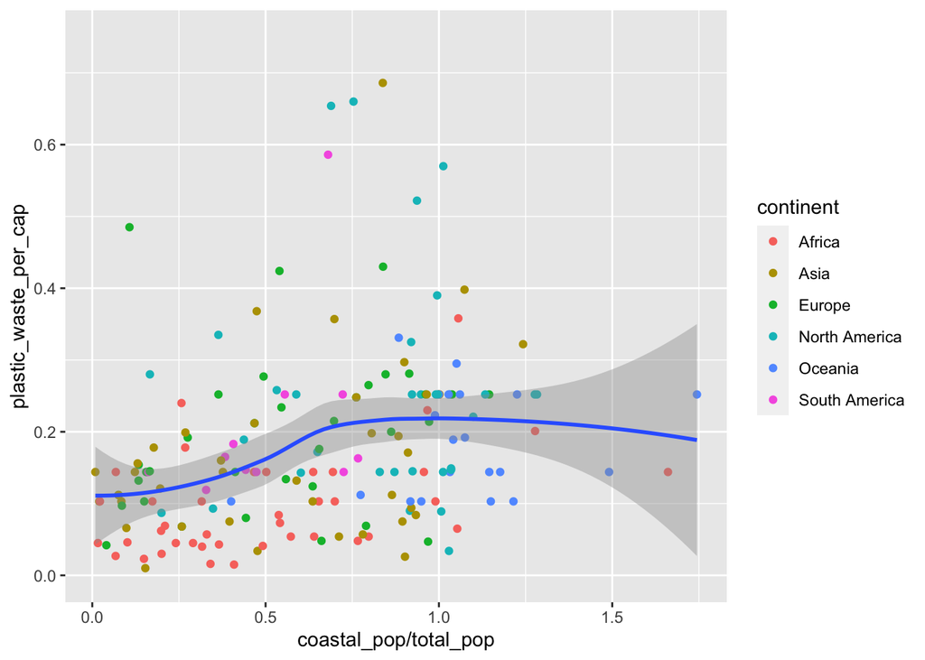

```r
ggplot(data = plastic_waste,
       mapping = aes(x = coastal_pop/total_pop, y = plastic_waste_per_cap)) +
       geom_point(aes(color = continent)) +
  geom_smooth() +
  ylim(0,0.75)
```